# Assessing Exercise Quality

Gabriel Martins Dias

17/03/2015

The goal of this report is to predict the manner in which people did their exercises based on the data from wearable sensors.

## Pre-processing

In order to make the results reproducible and consistent with future executions, we set a seed value.

```r
set.seed(1234)
```

## Fetching the training data

The data used for training was generated by accelerometers on the belt, forearm, arm, and dumbell of 6 participants. They were asked to perform barbell lifts correctly and incorrectly in 5 different ways, which were classified into different classes of movements.

```r
#fetch training data
download.file("https://d396qusza40orc.cloudfront.net/predmachlearn/pml-training.csv",
              destfile = "pml-training.csv",
              method = "curl")
data <- read.csv("pml-training.csv")
```

## Cleaning the data

First, let us observe a summary of the data:

```r
summary(data)
```

[output not shown]

First, we can remove the variables “X”, “user_name”, “raw_timestamp_part_1”, “raw_timestamp_part_2”, “cvtd_timestamp”, “new_window” and “num_window”, because they are only used to indentify the users and the tries, and are independent from the experiments.

```r
subset.data <- data[, -c(1,2,3,4,5,6,7)]
```

As we can observe, most of the features have a high number of NA’s. Therefore, we can start the process of cleaning the data by removing the variables with less than 90% of non-NA rows from the predictions.

```r
na.values <- is.na(subset.data)
na.rates <- colSums(na.values) / nrow(subset.data)

subset.data <- subset.data[ ,(na.rates < 0.1)]
```

The third step is to remove the columns after observing that they contain non-numeric data, because they also represent absence of data.

```r
non.numeric.values <- mapply(is.numeric, subset.data, SIMPLIFY = TRUE)
non.numeric.values["classe"] <- TRUE # avoid removing the outcome

subset.data <- subset.data[ , non.numeric.values]
print(class(subset.data$classe))
```

```
## [1] "factor"
```

## Creating a model

Given that the Random Forest algorithms include a cross validation, we will choose a K-fold cross validation (with K = $10$).

```r
trainIndex <- createDataPartition(subset.data$classe, p = 0.6, list = FALSE)
training <- subset.data[trainIndex, ]
testing <- subset.data[-trainIndex, ]

fit <- train(classe ~ .,
             data = training,
             method="rf",
             prox=TRUE,
             allowParallel=TRUE,
             trControl=trainControl(method = "cv", number = 10 ))

print(fit)
```

```
## Random Forest
##
## 11776 samples
##    52 predictor
##     5 classes: 'A', 'B', 'C', 'D', 'E'
##
## No pre-processing
## Resampling: Cross-Validated (10 fold)
##
## Summary of sample sizes: 10599, 10599, 10597, 10598, 10599, 10599, ...
##
## Resampling results across tuning parameters:
##
##   mtry  Accuracy   Kappa      Accuracy SD  Kappa SD
##    2    0.9900647  0.9874309  0.002684564  0.003396575
##   27    0.9896409  0.9868951  0.003141570  0.003973973
##   52    0.9852243  0.9813071  0.002439886  0.003085713
##
## Accuracy was used to select the optimal model using  the largest value.
## The final value used for the model was mtry = 2.
```

## Out of sample testing

As we split the data above into two sets (training / testing), we did not use the test set to set up the model. Now we can compare the outcomes from the predictions using the model created

```r
outcomes <- predict(fit, newdata = testing)
rate <- sum(testing$classe == outcomes) / length(outcomes)
print(rate)
```

```
## [1] 0.9917155
```

Therefore, the expected out of sample accuracy is $99.17\%$ (i.e., the expected error rate is $0.83\%$).

The following plot show the outcome of the predictions groupped by the real observations.

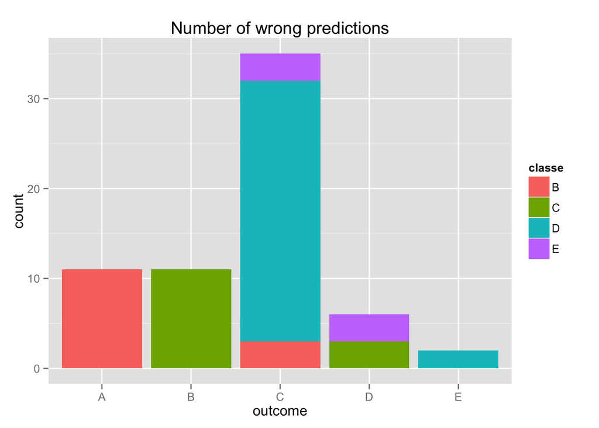

```r
# join the predictions and the real observations
# select only the wrong predictions (outcome != classe)
subset.wrong.predictions <- subset(cbind(testing, data.frame(outcome = outcomes)), outcome != classe)
ggplot(data = subset.wrong.predictions, aes(x = outcome, fill = classe)) +
        geom_histogram() +
        ggtitle("Number of wrong predictions")
```

We can observe that there were more errors when the class was predicted to be “C”.

## Submission

Let us run the prediction model created above through the real data for the submission.

```r
# fetch testing data
download.file("https://d396qusza40orc.cloudfront.net/predmachlearn/pml-testing.csv",
              destfile = "pml-testing.csv",
              method = "curl")
testing.real <- read.csv("pml-testing.csv")

outcomes <- predict(fit, newdata = testing.real)
print(outcomes)
```

```
##  [1] B A B A A E D B A A B C B A E E A B B B
## Levels: A B C D E
```